# The mixing-period tag treatment in the 2026 WCPO bigeye assessment

- Show All Code
- Hide All Code
- View Source

What `tag_flags(i,2)` can and cannot do, read against `bet.tag` and the fitted reporting rates

Published

August 12, 2026

**Scope**

This note is an executive summary of a methodological problem in the 2026 bigeye diagnostic model: the treatment of tag recaptures during the mixing period, controlled by `tag_flags(i,2)`. It computes, directly from `bet.tag` and the model’s flag settings, the two quantities that govern the problem — the share of recapture data resolved deterministically inside the mixing windows rather than scored as evidence, and the mixing-period recapture fraction $\hat\psi$ raised by the fitted fishery-specific reporting rates — and reads them against a companion simulation study (*Mixing-period tag recaptures in MULTIFAN-CL*, preliminary) whose results are quoted with provenance, not re-derived.

Everything computed here is parsed inline from the `.tag` and fitted `.par` inputs; everything quoted from the simulation study or reported from the assessment’s uncertainty grid is labelled as such. The recommendation at the end — a mixing-period likelihood as the resolution, and a tag-free fleets-as-areas configuration as a candidate structural alternative — follows from the demonstrated deficiencies of both flag settings. Appendix A1 of the 2026 bigeye full paper reports that the already-developed fleets-as-areas model gives comparable depletion and stock-status results; that result is cited here, not reproduced. No document in this series simulates a fleets-as-areas configuration.

**Input provenance**

Model inputs are pinned to [`ofp-sam-bet-2026-diagnostic`](https://github.com/PacificCommunity/ofp-sam-bet-2026-diagnostic) commit 8c2a586a8c5abec1a76e305f28f8f0b48fe2fe27. The tag file was resolved from cache at C:.Ducharme-Ba-tag-analysis\8c2a586a8c5abec1a76e305f28f8f0b48fe2fe27.tag; the fitted parameter file was resolved from cache at C:.Ducharme-Ba-tag-analysis\8c2a586a8c5abec1a76e305f28f8f0b48fe2fe27.par.

When no local overrides are supplied, the document reads `model/bet.tag` and `results/reference/final.par` from the pinned GitHub revision and caches them under inputs/cache.

**Disclaimer: use of AI assistance**

This note was prepared with the assistance of large language models. The model parsed `bet.tag`, transcribed the flag settings and the `tag fish rep` reporting-rate matrix from the supplied diagnostic `.par`, computed the diagnostics, and drafted the text.

Output produced this way requires independent verification, and the document is structured so that verification is possible rather than requiring trust:

- all computation is shown inline and runs in base R with no package dependencies;
- structural tripwires (`stopifnot`) check the parse against the file’s own recovery header before any result is used, so a parsing failure halts the render rather than producing wrong numbers;
- the R implementation mirrors an independently written and executed implementation; any divergence between the two will surface as a tripwire failure or as numbers differing from the companion diagnostic note (v2), which reports the same quantities;
- the per-group appendix permits any single row to be checked by hand against the `.tag` file in a few minutes;
- every value quoted from the simulation study is attributed to it, and every value reported from the assessment’s uncertainty grid is labelled as reported, not verified.

The inputs are read from a pinned upstream model revision or explicit local overrides. The parser’s section and dimension tripwires should still be checked before relying on the document. Conclusions and recommendations are the responsibility of the author, not of the tool.

**Parse fitted tag settings and define quoted comparison inputs**

```r
read_numeric_section <- function(path, marker, n_columns) {
  lines <- gsub("\r$", "", readLines(path, warn = FALSE))
  marker_at <- grep(paste0("^#\\s*", marker, "\\s*$"), lines,
                    ignore.case = TRUE)
  if (length(marker_at) != 1) stop("Expected one '# ", marker, "' section in ", path)
  next_marker <- grep("^#", lines[(marker_at + 1):length(lines)])[1]
  end_at <- if (is.na(next_marker)) length(lines) else marker_at + next_marker - 1
  rows <- trimws(lines[(marker_at + 1):end_at])
  rows <- rows[nzchar(rows)]
  fields <- strsplit(rows, "\\s+")
  if (!length(fields) || any(lengths(fields) != n_columns)) {
    stop("Malformed '# ", marker, "' section in ", path)
  }
  values <- suppressWarnings(as.numeric(unlist(fields, use.names = FALSE)))
  if (anyNA(values)) stop("Non-numeric value in '# ", marker, "' section in ", path)
  matrix(values, ncol = n_columns, byrow = TRUE)
}

tag_flags <- read_numeric_section(input_files$par$path, "tag flags", 10)
RR <- read_numeric_section(input_files$par$path, "tag fish rep", 33)
nmix <- tag_flags[, 1]

stopifnot(
  nrow(tag_flags) == 98,
  nrow(RR) >= 98,
  length(nmix) == 98,
  all(tag_flags[, 2] == 1),
  ncol(RR) == 33
)

RR <- RR[seq_len(98), , drop = FALSE]

# Regional seeding-prior means (SC22-SA-IP-05, purse seine), used only for comparison.
X_reg <- c(`1` = 0.5, `2` = 0.496, `3` = 0.512, `4` = 0.528, `5` = 0.5)

# --- Quoted from the companion simulation study (v11 fitted objects), not re-derived. ---
sim <- list(
  expD = data.frame(psi  = c(0.05, 0.30, 0.50),                    # Experiment D:
                    best = c(-0.039, -0.277, -0.509),              # bias in mixing-period F
                    worst= c(-0.048, -0.334, -0.599)),             # worst end = longest mixing
  floor_tau   = 0.22,     # survival floor; engages when removal fraction > 1 - tau = 0.78
  expE_N      = 125,      # Experiment E small-group design point
  expE_tail   = 0.060,    # share of groups with F-hat > 5x truth at that size
  expE_tail_big = 0.000,  # the same at 10,000 tags per group
  flag_gap_max  = 0.63)   # largest flag0-vs-truth gap in design (phi = 2, nmix = 4)
```

**Parse bet.tag (base R) with structural tripwires**

```r
lines <- gsub("\r$", "", readLines(input_files$tag$path))

hdr <- as.integer(strsplit(trimws(lines[2]), "\\s+")[[1]])
n_groups <- hdr[1]; n_bins <- hdr[3]
stopifnot(n_groups == 98)

rec_hdr_at <- grep("^# TAG RECOVERIES", lines)[1]
totals <- as.integer(strsplit(trimws(lines[rec_hdr_at + 2]), "\\s+")[[1]])
stopifnot(length(totals) == n_groups)

blk <- grep("^#\\s+[0-9]+\\s+-\\s+RELEASE REGION", lines)
stopifnot(length(blk) == n_groups)
ends <- c(blk[-1] - 1, length(lines))

groups <- vector("list", n_groups)
recs   <- vector("list", n_groups)
for (g in seq_len(n_groups)) {
  seg  <- lines[blk[g]:ends[g]]
  prog <- tail(strsplit(trimws(seg[1]), "\\s+")[[1]], 1)
  body <- seg[-1]
  keep <- !grepl("^\\s*#", body) & nzchar(trimws(body))
  body <- trimws(body[keep])
  relh <- as.integer(strsplit(body[1], "\\s+")[[1]])          # region, year, month
  rel  <- as.numeric(strsplit(body[2], "\\s+")[[1]])
  stopifnot(length(rel) == n_bins)
  rmat <- if (length(body) > 2) {
    do.call(rbind, lapply(strsplit(body[-(1:2)], "\\s+"), as.integer))
  } else matrix(integer(0), 0, 5)
  stopifnot(nrow(rmat) == totals[g])   # header row counts recovery records per group
  q <- if (nrow(rmat)) ((rmat[, 3] - relh[2]) * 12 + (rmat[, 4] - relh[3])) %/% 3L
       else integer(0)
  stopifnot(all(q >= 0), all(((rmat[, 3] - relh[2]) * 12 + (rmat[, 4] - relh[3])) %% 3 == 0))
  groups[[g]] <- data.frame(gid = g, prog = prog, region = relh[1], year = relh[2],
                            N = sum(rel))
  recs[[g]]   <- if (nrow(rmat)) data.frame(gid = g, q = q, fishery = rmat[, 2],
                                            n = rmat[, 5]) else NULL
}
grp <- do.call(rbind, groups)
rec <- do.call(rbind, recs)
stopifnot(identical(grp$prog, c(rep("RTTP", 15), rep("PTTP", 46), rep("JPTP", 37))))
stopifnot(n_groups == nrow(tag_flags), all(rec$fishery >= 1),
          all(rec$fishery <= ncol(RR)))

grp$nmix <- nmix
rec$rate <- RR[cbind(rec$gid, rec$fishery)]
rec$mix  <- rec$q < grp$nmix[rec$gid]

N_tot <- sum(grp$N); R_tot <- sum(rec$n)
# Note: the recovery header row counts records, not tags; it is checked per group above.
```

**The two governing quantities**

```r
# 1. Share of recapture data falling inside the configured mixing windows.
R_mix   <- sum(rec$n[rec$mix])
mix_share <- R_mix / R_tot

# 2. psi-hat per group: mixing returns raised by the fitted rate of the reporting
#    fishery (zero-rate returns flagged and excluded), divided by adjusted releases.
zero_mix <- sum(rec$n[rec$mix & rec$rate == 0])
raised <- with(rec[rec$mix & rec$rate > 0, ], tapply(n / rate, gid, sum))
grp$Rmix <- as.integer(with(rec[rec$mix, , drop = FALSE],
                            tapply(n, factor(gid, levels = 1:98), sum)))
grp$Rmix[is.na(grp$Rmix)] <- 0L
grp$psi <- 0; grp$psi[as.integer(names(raised))] <- raised
grp$psi <- grp$psi / grp$N
grp$psi_reg <- grp$Rmix / (X_reg[as.character(grp$region)] * grp$N)
grp$R <- with(rec, tapply(n, factor(gid, levels = 1:98), sum)); grp$R[is.na(grp$R)] <- 0

w_psi     <- sum(pmin(grp$psi, 1)     * grp$N) / N_tot
w_psi_reg <- sum(pmin(grp$psi_reg, 1) * grp$N) / N_tot
w_by_prog <- sapply(split(grp, grp$prog), function(d)
  sum(pmin(d$psi, 1) * d$N) / sum(d$N))

hi <- grp$psi >= 0.30
rec_hi <- sum(grp$R[hi]) / R_tot

# Switching flag=1 -> flag=0: extra raised removals by rate band.
band <- cut(rec$rate, c(-1, 0, 0.4, 0.95, 1.01),
            labels = c("zero-rate", "longline 0.16-0.26", "purse seine 0.46-0.84",
                       "JP coastal 0.99"))
extra <- with(rec[rec$mix & rec$rate > 0, ],
              tapply(n / rate - n, band[rec$mix & rec$rate > 0], sum))
extra[is.na(extra)] <- 0

# Counterfactual flag=0 floor margins under fitted rates and configured windows.
floor_util <- sapply(seq_len(98), function(g) {
  d <- rec[rec$gid == g & rec$mix & rec$rate > 0, , drop = FALSE]
  N <- grp$N[g]; u <- 0
  for (t in 0:(max(grp$nmix[g], 1) - 1)) {
    rt <- sum(d$n[d$q == t] / d$rate[d$q == t])
    if (N <= 0) return(Inf)
    u <- max(u, (rt / N) / (1 - sim$floor_tau)); N <- N - rt
  }
  u
})
n_floor <- sum(floor_util >= 1)
grp$raised_mix <- grp$psi * grp$N
grp$unremoved_flag1 <- pmax(grp$raised_mix - grp$Rmix, 0)
grp$floor_util_flag0 <- floor_util
```

**Minimal Experiment D calibration and forward_X proof of concept**

```r
# This deliberately small operating model is an executable illustration of the
# mechanism, not a re-run of the companion study or an assessment operating model.
baranov <- function(f, n, m) {
  z <- f + m
  (f / z) * (1 - exp(-z)) * n
}

om <- list(N0 = 10000, Tmax = 8, M = 0.20, F_true = 0.15,
           X_assumed = 0.50, nmix = 2L, phi = 1)

psi_of <- function(p, phi, nmix) {
  n <- p$N0
  total <- 0
  for (t in seq_len(nmix)) {
    total <- total + baranov(p$F_true * phi, n, p$M)
    n <- n * exp(-(p$F_true * phi + p$M))
  }
  total / p$N0
}

psi_closed <- function(p, phi, nmix) {
  z <- p$F_true * phi + p$M
  (p$F_true * phi / z) * (1 - exp(-nmix * z))
}

phi_for_psi <- function(target, nmix, p = om, phi_max = 30) {
  if (target <= 0) return(0)
  if (psi_of(p, phi_max, nmix) < target) return(NA_real_)
  uniroot(function(phi) psi_of(p, phi, nmix) - target,
          interval = c(1e-8, phi_max), tol = 1e-10)$root
}

bias_pred <- function(p, phi, nmix, x) {
  psi <- psi_of(p, phi, nmix)
  n_post <- p$N0 * exp(-(p$F_true * phi + p$M) * nmix)
  unremoved <- (1 - x) * psi * p$N0
  -unremoved / (n_post + unremoved)
}

# Matched-psi Experiment D calibration: expected, not Monte Carlo, results.
expd <- expand.grid(psi_target = c(0.05, 0.30, 0.50), nmix = 2:4)
expd$phi <- mapply(phi_for_psi, expd$psi_target, expd$nmix)
expd$psi <- mapply(function(phi, nmix) psi_of(om, phi, nmix),
                   expd$phi, expd$nmix)
expd$bias <- mapply(function(phi, nmix) bias_pred(om, phi, nmix, om$X_assumed),
                    expd$phi, expd$nmix)
stopifnot(
  all(is.finite(expd$phi)),
  max(abs(expd$psi - expd$psi_target)) < 1e-8,
  all(expd$bias < 0),
  all(abs(mapply(function(phi, nmix) psi_of(om, phi, nmix) -
                   psi_closed(om, phi, nmix),
                 expd$phi, expd$nmix)) < 1e-12)
)

# Conditional application of that approximation to this file. Each group is matched
# on its observed psi-hat and mixing length, using its effective fitted reporting rate.
eligible_reported <- with(rec[rec$mix & rec$rate > 0, ],
                          tapply(n, factor(gid, levels = 1:98), sum))
eligible_reported[is.na(eligible_reported)] <- 0
grp$x_effective <- ifelse(grp$raised_mix > 0, eligible_reported / grp$raised_mix, NA)
grp$phi_matched <- mapply(phi_for_psi, grp$psi, grp$nmix)
grp$flag1_bias_illustrative <- mapply(
  function(phi, nmix, x) {
    if (!is.finite(phi) || !is.finite(x) || x <= 0 || x > 1) return(NA_real_)
    bias_pred(om, phi, nmix, x)
  }, grp$phi_matched, grp$nmix, grp$x_effective)

# Minimal stochastic forward_X proof of concept.
posfun <- function(x, eps) {
  if (x >= eps) return(c(y = x, pen = 0))
  c(y = eps / (2 - x / eps), pen = (x - eps)^2)
}

solve_mixing_f <- function(target, n, m, iter = 25) {
  if (target <= 0) return(0)
  f <- -log(1 - min(target / n, 0.999))
  for (iteration in seq_len(iter)) {
    z <- f + m
    e <- exp(-z)
    gradient <- (f / z) * (1 - e) * n - target
    derivative <- n * ((m * (1 - e)) / z^2 + (f / z) * e)
    f <- max(f - gradient / derivative, 1e-10)
  }
  f
}

mix_step <- function(r, n, p, mode, floor = sim$floor_tau) {
  target <- if (mode == "flag0") r / p$X_assumed else r
  survival <- 1 - target / n
  floored <- survival < floor
  penalty <- 0
  if (floored) {
    adjusted <- posfun(survival - 0.02, floor - 0.02)
    survival <- 0.02 + adjusted[["y"]]
    penalty <- adjusted[["pen"]]
    target <- n * (1 - survival)
  }
  list(f = solve_mixing_f(target, n, p$M), penalty = penalty, floored = floored)
}

simulate_returns <- function(p, x_true) {
  n <- p$N0
  returns <- numeric(p$Tmax)
  for (t in seq_len(p$Tmax)) {
    f <- p$F_true * if (t <= p$nmix) p$phi else 1
    returns[t] <- rpois(1, x_true * baranov(f, n, p$M))
    n <- n * exp(-(f + p$M))
  }
  returns
}

nll_tag <- function(par, returns, p, mode, prior_sd = 0.25) {
  f_pop <- exp(par[1])
  phi <- if (mode == "forward_X") exp(par[2]) else 1
  x <- if (mode == "forward_X") plogis(par[3]) else p$X_assumed
  n <- p$N0
  nll <- 0
  for (t in seq_len(p$Tmax)) {
    if (t <= p$nmix && mode %in% c("flag0", "flag1")) {
      step <- mix_step(returns[t], n, p, mode)
      f <- step$f
      nll <- nll + 1000 * step$penalty
    } else {
      f <- if (t <= p$nmix) f_pop * phi else f_pop
      mu <- x * baranov(f, n, p$M) + 1e-10
      nll <- nll - dpois(returns[t], mu, log = TRUE)
    }
    n <- n * exp(-(f + p$M))
  }
  if (mode == "forward_X") {
    nll <- nll + 0.5 * ((log(x) - log(p$X_assumed)) / prior_sd)^2
  }
  nll
}

fit_one <- function(returns, p, mode) {
  if (mode %in% c("flag0", "flag1")) {
    interval <- log(c(1e-3, 5))
    fit <- optimize(function(log_f) nll_tag(c(log_f, 0, 0), returns, p, mode),
                    interval = interval, tol = 1e-9)
    return(c(F_hat = exp(fit$minimum), X_hat = p$X_assumed, conv = 0,
             at_bound = as.numeric(any(abs(fit$minimum - interval) < 1e-3))))
  }
  fit <- optim(c(log(0.10), log(1), qlogis(p$X_assumed)),
               function(par) nll_tag(par, returns, p, mode), method = "Nelder-Mead",
               control = list(maxit = 3000, reltol = 1e-10))
  c(F_hat = exp(fit$par[1]), X_hat = plogis(fit$par[3]), conv = fit$convergence,
    at_bound = 0)
}

set.seed(20260810)
n_sim <- 100
forward_design <- expand.grid(x_true = c(0.35, 0.50, 0.65),
                              nmix = 2:4,
                              phi = c(0.5, 1.0, 2.0),
                              mode = c("flag0", "flag1", "forward_X"),
                              replicate = seq_len(n_sim), KEEP.OUT.ATTRS = FALSE)
forward_res <- do.call(rbind, lapply(seq_len(nrow(forward_design)), function(row) {
  setting <- forward_design[row, ]
  scenario_om <- modifyList(om, list(nmix = setting$nmix, phi = setting$phi))
  fit <- fit_one(simulate_returns(scenario_om, setting$x_true), scenario_om, setting$mode)
  data.frame(x_true = setting$x_true, nmix = setting$nmix, phi = setting$phi,
             mode = setting$mode,
             F_hat = fit[["F_hat"]], X_hat = fit[["X_hat"]],
             conv = fit[["conv"]], at_bound = fit[["at_bound"]])
}))
forward_res$rel_bias <- forward_res$F_hat / om$F_true - 1
forward_plot <- do.call(rbind, lapply(split(forward_res[forward_res$conv == 0, ],
                                             list(forward_res$x_true[forward_res$conv == 0],
                                                  forward_res$nmix[forward_res$conv == 0],
                                                  forward_res$phi[forward_res$conv == 0],
                    forward_res$mode[forward_res$conv == 0]),
                  drop = TRUE),
  function(d) data.frame(x_true = d$x_true[1], nmix = d$nmix[1], phi = d$phi[1],
                         mode = d$mode[1], lo = unname(quantile(d$rel_bias, 0.25)),
                         mid = median(d$rel_bias), hi = unname(quantile(d$rel_bias, 0.75)))))

# Retain the original baseline table as a compact diagnostic alongside the
# expanded figure. The plot below displays the complete crossed design.
baseline_res <- forward_res[forward_res$nmix == 2 & forward_res$phi == 1, ]
forward_summary <- do.call(rbind, lapply(split(baseline_res,
                                                list(baseline_res$x_true,
                                                     baseline_res$mode), drop = TRUE),
  function(d) data.frame(`True reporting rate` = d$x_true[1], Treatment = d$mode[1],
                         `Median F bias` = median(d$rel_bias),
                         `Forward_X convergence` = mean(d$conv == 0),
                         `Flag endpoint contact` = mean(d$at_bound == 1),
                         check.names = FALSE)))
forward_summary <- forward_summary[order(forward_summary[[1]], forward_summary[[2]]), ]
stopifnot(
  nrow(forward_plot) == 3L * 3L * 3L * 3L,
  all(forward_plot$lo <= forward_plot$mid & forward_plot$mid <= forward_plot$hi),
  !any(forward_res$at_bound[forward_res$mode %in% c("flag0", "flag1")] == 1)
)
```

**Estimated reporting rates and the mixing-period likelihood terms**

```r
# Term-content check: reporting rate is now estimated with a log-scale tag-seeding
# prior (the forward_X prior), while the flag removals run as before. The
# mixing-period likelihood terms are formed exactly as MULTIFAN-CL forms them:
# predicted reported returns equal the estimated rate times the removal the flag
# actually made (baranov() of the solved mixing F equals the realized, possibly
# floored, removal — the analogue of tagcatch built from nrfm). Each condition is
# fitted with the mixing terms included and excluded on identical data; the
# difference isolates what the terms alone do.

mix_step_est <- function(r, n, p, x, raised) {
  mix_step(r, n, modifyList(p, list(X_assumed = x)),
           if (raised) "flag0" else "flag1")
}

nll_estimated_x <- function(par, returns, p, raised, include_mix,
                            prior_sd = 0.25) {
  f_pop <- exp(par[1])
  x <- plogis(par[2])
  n <- p$N0
  nll <- 0
  for (t in seq_len(p$Tmax)) {
    if (t <= p$nmix) {
      step <- mix_step_est(returns[t], n, p, x, raised)
      f <- step$f
      nll <- nll + 1000 * step$penalty
      if (include_mix) {
        mu <- x * baranov(f, n, p$M) + 1e-10
        nll <- nll - dpois(returns[t], mu, log = TRUE)
      }
    } else {
      f <- f_pop
      mu <- x * baranov(f, n, p$M) + 1e-10
      nll <- nll - dpois(returns[t], mu, log = TRUE)
    }
    n <- n * exp(-(f + p$M))
  }
  nll + 0.5 * ((log(x) - log(p$X_assumed)) / prior_sd)^2
}

# Deterministic structure checks on a non-floored expected-return realization:
# the mixing-term block is invariant to the estimated rate under the raised
# removal (the cancellation) and strictly decreasing toward X = 1 under the
# face-value removal (the pseudo-data property).
expected_returns <- function(p, x_true) {
  n <- p$N0
  sapply(seq_len(p$Tmax), function(t) {
    f <- p$F_true * if (t <= p$nmix) p$phi else 1
    out <- x_true * baranov(f, n, p$M)
    n <<- n * exp(-(f + p$M))
    out
  })
}

mixing_term_block <- function(x, returns, p, raised) {
  n <- p$N0
  block <- 0
  for (t in seq_len(p$nmix)) {
    step <- mix_step_est(returns[t], n, p, x, raised)
    mu <- x * baranov(step$f, n, p$M) + 1e-10
    block <- block - dpois(returns[t], mu, log = TRUE)
    n <- n * exp(-(step$f + p$M))
  }
  block
}

det_returns <- round(expected_returns(om, om$X_assumed))
x_grid <- seq(0.35, 0.95, by = 0.05)
block_raised <- sapply(x_grid, mixing_term_block, returns = det_returns,
                       p = om, raised = TRUE)
block_face   <- sapply(x_grid, mixing_term_block, returns = det_returns,
                       p = om, raised = FALSE)

# Prior widths: 0.25 is the weak single-group prior used above; 0.05 is a
# tight tag-seeding prior, standing in for the stronger reporting-rate
# information an assessment carries. Both are swept so the prose does not
# have to assume how much the prior resists the pull.
prior_sds <- c(0.25, 0.05)

estx_res <- do.call(rbind, lapply(prior_sds, function(prior_sd) {
  do.call(rbind, lapply(c(0.35, 0.50, 0.65), function(x_true) {
    do.call(rbind, lapply(seq_len(n_sim), function(replicate) {
      # Data depend on the condition and replicate only, so the paired
      # include/exclude and prior-width fits see identical returns.
      set.seed(20260811 + 1000 * round(100 * x_true) + replicate)
      returns <- simulate_returns(om, x_true)
      do.call(rbind, lapply(c(FALSE, TRUE), function(raised) {
        do.call(rbind, lapply(c(TRUE, FALSE), function(include_mix) {
          fit <- optim(c(log(0.10), qlogis(om$X_assumed)),
                       function(par) nll_estimated_x(par, returns, om,
                                                     raised, include_mix,
                                                     prior_sd),
                       method = "Nelder-Mead",
                       control = list(maxit = 3000, reltol = 1e-10))
          data.frame(prior_sd = prior_sd, x_true = x_true, raised = raised,
                     include_mix = include_mix, replicate = replicate,
                     F_hat = exp(fit$par[1]), X_hat = plogis(fit$par[2]),
                     conv = fit$convergence)
        }))
      }))
    }))
  }))
}))
estx_res$rel_bias <- estx_res$F_hat / om$F_true - 1

estx_ok <- estx_res[estx_res$conv == 0, ]
med_x <- with(estx_ok, tapply(X_hat, list(x_true, raised, include_mix,
                                          prior_sd), median))
med_f <- with(estx_ok, tapply(F_hat, list(x_true, raised, include_mix,
                                          prior_sd), median))

estx_summary <- do.call(rbind, lapply(
  split(estx_ok, interaction(estx_ok$prior_sd, estx_ok$x_true,
                             estx_ok$raised, estx_ok$include_mix,
                             drop = TRUE)),
  function(d) data.frame(
    `Prior sd` = d$prior_sd[1],
    `True X` = d$x_true[1],
    Removal = if (d$raised[1]) "raised (flag 0)" else "face value (flag 1)",
    `Mixing terms` = if (d$include_mix[1]) "included" else "excluded",
    `Median fitted X` = round(median(d$X_hat), 3),
    `Median F bias` = median(d$rel_bias),
    Converged = nrow(d) / n_sim,
    check.names = FALSE)))

# Tripwires: the render fails if any structural or directional claim in the
# prose stops holding. Directions are enforced here, not asserted in the text.
stopifnot(
  # cancellation: raised-removal mixing terms invariant to the estimated rate
  max(block_raised) - min(block_raised) < 1e-6,
  # pseudo-data: face-value mixing terms strictly favour X = 1
  all(diff(block_face) < 0),
  # the pull on the fitted rate, in every face-value condition and at
  # both prior widths
  all(med_x[, "FALSE", "TRUE", ] > med_x[, "FALSE", "FALSE", ]),
  # its downstream expression through a lower fitted F, likewise
  all(med_f[, "FALSE", "TRUE", ] < med_f[, "FALSE", "FALSE", ]),
  # inertness carries through to estimation under the raised removal
  all(abs(med_x[, "TRUE", "TRUE", ] - med_x[, "TRUE", "FALSE", ]) < 0.02),
  # the tighter prior resists the pull without eliminating it: the
  # face-value inflation is smaller than under the weak prior, and still
  # present, in every condition
  all(med_x[, "FALSE", "TRUE", "0.05"] < med_x[, "FALSE", "TRUE", "0.25"])
)

# Inline values, weak and tight prior, at the design-centre true rate.
pull_x  <- med_x["0.5", "FALSE", "TRUE",  "0.25"]
base_x  <- med_x["0.5", "FALSE", "FALSE", "0.25"]
pull_f  <- med_f["0.5", "FALSE", "TRUE",  "0.25"] / om$F_true - 1
base_f  <- med_f["0.5", "FALSE", "FALSE", "0.25"] / om$F_true - 1
tpull_x <- med_x["0.5", "FALSE", "TRUE",  "0.05"]
tbase_x <- med_x["0.5", "FALSE", "FALSE", "0.05"]
tpull_f <- med_f["0.5", "FALSE", "TRUE",  "0.05"] / om$F_true - 1
tbase_f <- med_f["0.5", "FALSE", "FALSE", "0.05"] / om$F_true - 1
```

# How MULTIFAN-CL treats mixing returns

The design has a defensible rationale. During mixing, tagged fish are by definition not distributed like the population, so a prediction of their recaptures from population-average availability is knowingly misspecified, and scoring returns against it would manufacture information rather than extract it. Declining to fit them is the same instinct as setting aside a series whose selectivity cannot be modelled. What makes the mixing period harder than that case is that the returns cannot simply be dropped: those fish have left the tagged population, and failing to remove them would inflate the cohort against which every later, legitimately fitted return is scored. The data must therefore be used even where they cannot be fitted.

The issue is not that MULTIFAN-CL lacks a tag likelihood. **After mixing**, it projects the tagged population with the population fishing mortality, predicts reported returns as expected recaptures multiplied by the reporting rate, and scores those returns in the tag likelihood. **During mixing**, it instead uses observed returns to solve deterministically for a tag-specific removal that fixes the tagged population state. The mixing returns are never scored as evidence about that state under either flag setting — although, as the next subsection sets out, likelihood terms for them are still formed, with consequences that differ between the settings.

| `tag_flags(i,2)` | Mixing-period removal target | Mixing returns in the likelihood | Principal failure mode |
| --- | --- | --- | --- |
| 0 | $R_{obs} / X$ | Present but inert: predicted reported returns reproduce the observations by construction | Conditionally valid only if the assumed reporting rate is right, the survival floor is inactive, and the release-group inversion is informative. |
| 1 | $R_{obs}$ | Present and mis-scaled: predicts $X R_{obs}$ against $R_{obs}$ | Assumes complete reporting and systematically under-removes wherever $X < 1$; when rates are estimated, the mis-scaled terms act as pseudo-data for complete reporting (details). |

Here $R_{obs}$ is the reported return and $X$ is its reporting rate. The first setting raises observed returns for non-reporting before removal; the second treats reported returns as true recaptures. Neither treatment scores the mixing returns as evidence about the tagged-population state: the removal is solved to reproduce its target exactly, with no uncertainty attached and no ability for the model to object. This is why choosing a flag is not a likelihood-based treatment of the data.

## What the likelihood terms contain

SA-WP-06 §5.4.2 describes the treatment two ways: that mixing-period tags “do not contribute to the tagging likelihood component”, and that the treatment “desensitizes the likelihood function”. The second formulation is the accurate one. In the source (June 2025 public release, v2.2.7.6), the tag likelihood loops from the release period with no mixing-window offset — `fit_tag_returns` in `tagfit.cpp` iterates from `initial_tag_period(it,ir)` — so a likelihood term is formed and summed for every mixing-period return under both flag settings. What matters is what the terms contain, because the two settings differ here in a way the table above records.

Under `tag_flags(i,2) = 0`, the Newton–Raphson removal drives the model’s true recaptures onto $R_{obs}/X$, and the likelihood then predicts reported returns as $X$ times those recaptures: the fishery-period totals reproduce the observations identically, the reporting rate cancels between removal target and prediction, and the terms are informationally inert up to the age allocation of a constrained total. Under `tag_flags(i,2) = 1`, the cancellation fails: the removal drives true recaptures onto $R_{obs}$, so the likelihood predicts $X R_{obs}$ against an observation of $R_{obs}$. That term is minimized at $X = 1$ regardless of the data, so wherever reporting is incomplete, each mixing return enters the objective as pseudo-data for complete reporting — with a live gradient on the reporting-rate parameters whenever those rates are estimated, as they are in this assessment. The code corroborates the mismatch: the fit-report writers apply a corrected reporting-rate multiplier during Newton–Raphson periods (`get_rep_rate_correction`, `tag3.cpp`), but the likelihood path does not.

Two effects therefore need separating. The *removal* effect — how many tags are deleted — operates through the tagged-population state, exists with all reporting rates fixed, and is the subject of the companion simulation study and of everything above. The *term-content* effect exists only under `tag_flags(i,2) = 1` with estimated reporting rates, and pulls the fitted rates toward one against their tag-seeding priors. The companion study fixes the assumed rate throughout, which deactivates the term-content effect by construction — and deactivates it in MULTIFAN-CL under the same conditions, since with rates fixed the mis-scaled terms are constants in the remaining parameters — so its results are unaffected by this section. The minimal check below verifies both halves of that statement by simulation at two reporting-rate prior widths, with the direction of the pull enforced by tripwires rather than asserted. In this file, 43.6% of the reported recaptures sit inside the mixing windows, so under the configured setting that share of the data participates in reporting-rate estimation as pseudo-data rather than as evidence.

The distinction that matters is between desensitizing the likelihood and desensitizing the model. The first is what the design intends and what the quoted rationale describes; the second is not achieved. Mixing returns retain full authority over the tagged population state — more authority than fitted data would carry, because a fitted observation can be outweighed by other information and a deterministic constraint cannot. Their influence is relocated from a channel with residuals and error propagation to one with neither, so the same returns are treated as too unreliable to inform parameters and reliable enough to fix the population state exactly. Determinism is also not the only way to honour the stated intent: inflating the variance of mixing-period predictions, or downweighting them, would reduce their leverage while preserving error propagation, whereas a deterministic solve places unbounded weight on the channel the rationale has just described as untrustworthy.

Desensitization is therefore appropriate under three conditions: that the removal target is approximately right, that the affected share of the data is small enough for its unpropagated error to be immaterial, and that the treatment declines to extract information rather than injecting misinformation. For this file none of the three holds. The target depends on the reporting rates, which are the quantity in dispute; the affected share is 43.6% of reported recaptures; and under the configured setting the terms do not merely abstain but argue for complete reporting. The survival floor, treated next, breaches the first condition in a further way, by silently departing from the removal target the flag specifies.

A consequence for $\hat\psi$: the fitted rates used for raising were estimated under `tag_flags(i,2) = 1`. To whatever extent the term-content effect has moved them upward, raising by them understates $\hat\psi$, so the diagnostic in this note is conservative in the direction that favours the configured setting.

## Why `tag_flags(i,2) = 1` exists

`tag_flags(i,2) = 1` exists to provide an escape from a failure mode of the original, rate-raised treatment. Under `tag_flags(i,2) = 0`, MULTIFAN-CL divides a reported mixing-period return by its assumed reporting rate before removing tags. This is the natural correction for incomplete reporting, but it can become numerically and biologically implausible when the raised removal is large relative to the tagged cohort.

The survival-floor pathology is what happens next. With a low reporting rate, a large observed return, or both, the implied removal in one mixing period can leave fewer tags than MULTIFAN-CL permits to survive. The model then applies `posfun`: it floors survival and rescales removal to the amount consistent with that floor. Rather than removing $R_{obs}/X$, it removes less. The raised treatment therefore becomes an under-removal treatment at precisely the point it was intended to correct under-reporting, pulling inferred $F$ downward and biomass upward.

Flag 1 avoids that rate-raised floor pathway by removing only $R_{obs}$. It does not solve the statistical problem. It trades a conditional cap pathology for the unconditional assumption that reporting is complete, so it under-removes whenever $X < 1$, whether or not the floor would have engaged under flag 0.

For this file, the fitted fishery-specific reporting rates and configured mixing windows screen 2 group(s) as reaching the configured floor under flag 0, rather than the six groups suggested by regional-mean raising. This makes the floor a targeted flag-0 fit diagnostic, not a general reason to select flag 1 and not evidence that it is absent. The current rates were fitted under flag 1 and would re-equilibrate under flag 0; an actual flag-0 fit must identify any floor engagements and their objective-function contribution.

**Which Newton-Raphson routine the build calls**

`tag3.cpp` contains more than one definition of the tag Newton-Raphson solve, and they differ on exactly the two features this section relies on. The routine described above branches on `tag_flags(i,2)` and applies the survival floor. A second definition, `do_newton_raphson_for_tags2`, forms `actual_tag_catch` as `tot_tag_catch/(1e-6 + rep_rate)` with no `tag_flags(i,2)` test — it raises unconditionally — and although it computes `surv_rate`, it never uses it, so no floor is applied. A third definition sits inside a comment block and is dead. **We have not confirmed which routine the assessment build compiles and calls.**

The assessment’s own reported results settle part of this. The flag is a level of the uncertainty grid, and the grid outputs reported above differ by level: the status determination changes when the ensemble is restricted to `tag_flags(i,2) = 0`. A build routed solely through `do_newton_raphson_for_tags2` would ignore the flag, both levels would return the same fit, and no such difference could arise. The flag also has no effect on estimation outside the Newton-Raphson removal — its only other appearance is in the fit-report writers — so the routine the assessment estimates with is one that branches on it. Consistent with this, the flag was inert in MULTIFAN-CL before v2.2.7.6, which is the behaviour of a build that formerly routed through a flag-blind routine. What is not settled is whether the live routine also carries the survival floor.

The uncertainty is therefore bounded by this section. Were the live routine to lack the floor, the rationale set out above for preferring flag 1 would not arise, the group screen would not apply, and condition 1 of the guidance below would be satisfied vacuously. Everything else stands: flag 1 still under-removes wherever $X < 1$, flag 0 remains conditional on the assumed reporting rate and on release-group size, the two settings still fail to bracket the truth, and the mixing returns are still not scored as evidence about the tagged population (What the likelihood terms contain). In that case the argument against flag 0 is weaker and the argument against flag 1 unchanged, so the direction of the guidance is unaffected. A flag-0 fit reporting its floor engagements and `posfun` contribution would resolve the question empirically, which is a further reason for condition 1.

**Weight on the floor penalty**

When the floor engages, the `posfun` penalty enters the objective as `penwt * tmp`, with `penwt = 1.0` unless `age_flags(117)` is set: positive gives `age_flags(117)/1e8`, which is effectively zero, and negative gives zero outright. `age_flags(117)` is 0 in the diagnostic model, so the default weight applies. The minimal simulations below charge the penalty at 1000 times the `posfun` return, which makes flooring markedly harder to accept there than in MULTIFAN-CL. The difference is conservative for the argument — the model tolerates flooring more readily than these results imply — but it also means the objective-function contribution asked for in condition 1 will be small enough to overlook unless it is reported deliberately.

# Summary

**Two structural facts frame everything.** First, under the configured mixing windows, 3,605 of the 8,259 reported recaptures in `bet.tag` — **43.6% of the tagging data** — are never scored as evidence about the tagged population. Under either setting of `tag_flags(i,2)`, those returns fix the tagged population state deterministically, with full authority and no uncertainty attached. Their likelihood terms still exist but are constructed from the observations themselves: inert under the raised setting, mis-scaled under the configured face-value setting, where they act as pseudo-data for complete reporting whenever rates are estimated (What the likelihood terms contain). Second, the removal that fixes that state depends entirely on what is assumed about reporting rates during mixing, and the model’s own fitted `tag fish rep` matrix says those rates are far from uniform: near-complete (0.99) for the Japanese coastal fisheries that dominate JPTP returns, roughly one half (0.46–0.50) for the main purse-seine fisheries that dominate PTTP and RTTP returns, and 0.16–0.26 for longline.

**The configured setting, `tag_flags(i,2) = 1`, removes reported mixing-period returns at face value — equivalent to assuming complete reporting — and its cost falls almost entirely on the purse-seine programmes.** By the model’s own fitted rates the assumption is nearly true for JPTP (weighted $\hat\psi$ = 0.117; 93% of JPTP mixing returns come from the 0.99-rate fisheries) and substantially false for RTTP (0.303) and PTTP (0.168), where roughly a third to a half of true mixing recaptures are never removed. The companion study’s Experiment D maps $\hat\psi$ to the downward bias in mixing-period $F$: 3.9%–4.8% at $\psi$ = 0.05, 27.7%–33.4% at 0.3, and 50.9%–59.9% at 0.5, the worse end at longer mixing. 20 release groups sit at $\hat\psi \ge 0.3$, carrying 31% of the reported recaptures. The bias is systematic — $F$ low, scale high, every group the same direction — and its one merit is that it is predictable in advance from exactly this calculation.

**The alternative, `tag_flags(i,2) = 0`, raises returns by the assumed rate before removal, and is unbiased only under conditions this file does not fully meet.** Its accuracy moves one-for-one with the reporting rates, which are the quantity under dispute, weakly informed for longline, and being revised downward. Its inversion is convex in a noisy observation, so small release groups put weight in the upper tail of $F$: at the study’s 125-tag design point, 6.0% of simulated groups returned estimates more than five times the truth with everything else correct, invisible to median-based diagnostics — and 54 of the 98 groups here are that small or smaller. The oft-cited floor pathology, by contrast, largely dissolves under the fitted rates: re-evaluated with fishery-specific raising and the configured windows, 2 group(s) breach the survival-floor condition, not the six that regional-mean raising suggests. And the switch is surgically targeted: moving to raised removals adds 1,727 tags to the purse-seine and longline removals — where the face-value bias lives — while changing JPTP by 3 tags in total.

**Running both settings as levels of the uncertainty grid does not bound the problem.** The pair is structurally one-sided: because the assumed rate is below one wherever it matters, the raised treatment always removes more tags and always returns the larger $F$. Two grid levels therefore span an assumption without bracketing the truth — they cannot contain it at all when the assumed rate is too high — and, because one level carries a documented directional bias, averaging them functions as a fifty per cent weighting on that bias, not as an uncertainty representation.

**This is not academic: the choice reportedly flips the status determination.** With both settings in the grid, the ensemble indicates the stock is not overfished and not undergoing overfishing; restricted to `tag_flags(i,2) = 0`, it indicates overfished and about as likely as not undergoing overfishing. Those ensemble results are reported here, not verified, but their direction is exactly what the $\hat\psi$ analysis predicts, and the guidance against the grid axis was fixed before the ensemble outcome was known. The honest statement of status is therefore not either determination — it is that the determination currently turns on a model component that is biased under both of its available settings.

# Assessment guidance

## First-level guidance: resolve or replace the tagged formulation

**The resolution follows from the same reasoning that motivated the current treatment.** If mixing returns cannot be fitted because recaptures cannot be predicted from an unmixed cohort, then estimating the departure from mixing removes the obstacle rather than working around it. A single parameter suffices in the proof of concept: a mixing-period availability multiplier $\varphi$ on the tagged cohort’s fishing mortality, in place of the untestable assertion that tagged fish are as available as the population. The mixing assumption then becomes an estimate with a standard error that the returns can contradict, instead of a constraint imposed on them. This is a continuation of the original design intent, not a rejection of it.

**The resolution is a mixing-period likelihood.** During mixing, MULTIFAN-CL should project the tagged cohort, predict reported returns as $X C$, score those returns against the observations, and estimate reporting rates against their tag-seeding priors. This would put 44% of the tag data back into estimation and remove the deterministic inversion. The companion simulation’s `forward_X` treatment recovers $F$ under reporting-rate misspecification that biases both flags, but it is not free: when release groups are small, estimating fishing mortality, mixing availability, and reporting rates together can be imprecise. This is a MULTIFAN-CL redevelopment and validation task, not a configuration change for the current assessment — though a smaller one than it may appear: likelihood terms for the mixing returns already exist in the code, and what changes is the origin of their predictions, generated from the projected cohort rather than constructed from the observations.

Formally, for release group $i$, period $t$, and fishery $f$, `forward_X` advances the tagged cohort $N_{it}$ using a mixing-period fishing mortality $F^T_{it}$ and natural mortality $M$, forms true recaptures $C_{itf}$ from that state, and predicts

$$\mu_{itf} = X_{if} C_{itf}.$$

The mixing return then contributes an observation likelihood, for example $R_{itf} \sim \operatorname{Poisson}(\mu_{itf})$, instead of a deterministic removal target. A tag-seeding prior supplies information on the reporting rate, such as a penalty on $\log X_{if}$ around its prior mean. In the proof of concept, the free parameters are population fishing mortality ($\log F$), a mixing-period availability multiplier ($\log \varphi$), and reporting rate ($\operatorname{logit}X$). The flags estimate none of the latter two from mixing returns; they solve for whatever mixing-period removal reproduces their chosen target. `forward_X` consequently lets the data, process, and prior disagree in an estimable way, but it can be weakly identified when many small release groups must inform all three quantities.

**A tag-free fleets-as-areas model is also a credible path for model development and management advice.** Appendix A1 of the [2026 bigeye full paper](https://meetings.wcpfc.int/node/32657) reports that the already-developed, spatially implicit fleets-as-areas model has comparable depletion and stock-status results to the current tagged model. That agreement is reported here, not reproduced. Subject to its own fit and diagnostic evaluation, this is a candidate full assessment model and may be included in the structural uncertainty grid. It represents uncertainty in the combined data-and-spatial formulation, not a correction for the tag flags or an estimate of their isolated effect. It does not validate the tagged model’s mixing-period treatment.

## Second-level guidance: the tagged spatial branch

For this tag file, `tag_flags(i,2) = 1` should not be retained as the selected tagged configuration. It removes reported returns at face value even though the mixing returns that matter most are not fully reported: weighted $\hat\psi$ is 0.303 for RTTP and 0.168 for PTTP, compared with 0.117 for JPTP. 20 groups with $\hat\psi \ge 0.3$ carry 31% of all reported recaptures. The configured face-value treatment therefore imposes its known directional bias on a material share of the data, concentrated in programmes with purse-seine reporting rates near one half. It also carries the second defect: with reporting rates estimated, its mixing-period likelihood terms are pseudo-data for complete reporting, so the fitted rates that scale every post-mixing prediction are themselves in question under this setting; the natural check is a comparison of fitted rates against their tag-seeding priors between the two flag settings. It can remain a documented diagnostic sensitivity, but not an equally weighted grid level or a bounding endpoint.

If a tagged spatial branch must be retained before either first-level path is available, `tag_flags(i,2) = 0` is the provisionally preferable single setting, with three explicit conditions attached to this file:

1. **Confirm floor behaviour in an actual flag-0 fit.** The fitted-rate screen identifies 2 group(s) whose raised mixing removal reaches the configured survival floor. That is substantially less than the regional-mean screen suggests, but it is not a clean pass: fitted reporting rates would re-equilibrate after the flag changes. The actual fit must report the affected group(s), the `posfun` contribution, and the resulting floor utilization before its outputs are used for advice.
2. **Treat small-group inversion as a tail diagnostic, not a median diagnostic.** 54 of the 98 release groups contain 125 tags or fewer. The simulation result implies that their raised-return inversions can produce an upper tail in $F$ even with correct reporting rates and an inactive floor. The flag-0 run should therefore report group-level implied mixing mortality and any optimizer-bound or extreme-return diagnostics, rather than relying on a pooled median or likelihood summary.
3. **Represent reporting-rate uncertainty directly.** Switching to flag 0 raises 1,727 mixing returns in the purse-seine and longline rate bands, but only 3 in the near-complete-reporting Japanese coastal band. The change is therefore driven by precisely the reporting rates under active scrutiny. Sensitivity to their priors or fixed assumptions belongs in the tagged-model diagnostic set; replacing it with a flag-1 grid level would hide rather than represent that uncertainty.

The 0 zero-rate mixing returns are unresolved under either choice and should be traced separately. Neither setting converts the excluded 44% of recaptures into probabilistic evidence, so this provisional choice does not remove the case for the likelihood redevelopment or the tag-free fleets-as-areas alternative.

# The $\hat\psi$ table

For release group $i$, the empirical diagnostic in this note is

$$\hat\psi_i = \frac{1}{N_i}\sum_{t < n_{mix,i}}\sum_f
\frac{R_{itf}}{\hat X_{if}},$$

where $R_{itf}$ is a reported mixing-window return from fishery $f$, $\hat X_{if}$ is its fitted reporting rate, and $N_i$ is the correction-adjusted release count. Thus $\hat\psi_i$ estimates the fraction of the group truly recaptured while the mixing rule is active; it is not the fraction merely reported. Omitting the raising returns $X\psi$ rather than $\psi$ — roughly half the diagnosed fraction at purse-seine rates, and because the bias steepens in $\psi$, less than half the diagnosed consequence.

The companion simulation explains why this quantity governs `tag_flags(i,2) = 1`. That setting removes $R$ where it should remove the true recaptures $C$, leaving roughly $(1-X)\psi N_0$ extra tags at liberty. In the stripped-down operating model this gives the approximation

$$\frac{\hat F}{F} \approx
\frac{N_{post}}{N_{post} + (1-X)\psi N_0},$$

so the effect is systematically toward lower $F$ and higher biomass. This is an analytical interpretation of the simulation, not a fitted assessment prediction. 0 mixing returns come from a fishery whose fitted rate is zero and cannot be raised at all; they are excluded, which understates $\hat\psi$ for the affected groups, and the inconsistency should be resolved regardless of the flag choice.

| psi class | Groups | Share of recaptures | Experiment D bias class (mixing-period F) |
| --- | --- | --- | --- |
| < 0.05 | 36 | 16.6% | a few per cent |
| 0.05–0.30 | 42 | 52.7% | up to roughly one third |
| 0.30–0.50 | 10 | 20.8% | roughly one third to one half |
| ≥ 0.50 | 10 | 10.0% | one half or more |

| Programme | Groups | Releases | Mixing returns | Weighted psi (fishery rates) | (regional means) |
| --- | --- | --- | --- | --- | --- |
| RTTP | 15 | 3,080 | 551 | 0.303 | 0.357 |
| PTTP | 46 | 23,766 | 2,746 | 0.168 | 0.222 |
| JPTP | 37 | 3,422 | 308 | 0.117 | 0.180 |

The programme contrast carries the story: the face-value assumption is nearly correct where the fitted rates are near one, and costs a third to a half of the true mixing removals where they are near one half — which is where 89% of the releases sit.

## Conditional implication for this tag file

The following envelope applies the stripped-down Experiment D approximation to each release group’s observed $\hat\psi$, mixing length, and effective fitted reporting rate. It is not an assessment estimate of $F$ bias: it holds the operating model’s natural mortality and post-mixing fishing mortality fixed, infers the availability needed to produce the observed $\hat\psi$, and then asks what `tag_flags(i,2) = 1` would imply in that simplified setting. Its purpose is to make the direction and potential scale of the known face-value bias explicit for this file.

| Programme | Calibrated groups | Weighted psi | Illustrative F bias range |
| --- | --- | --- | --- |
| RTTP | 15 | 0.303 | -78% to -2% |
| PTTP | 35 | 0.168 | -87% to -0% |
| JPTP | 26 | 0.117 | -96% to -0% |

# Mechanism checks

This table makes the deterministic difference between the two flags auditable from the same inputs as the $\hat\psi$ calculation. `Raised mixing returns` is the removal target under `tag_flags(i,2) = 0`; `reported mixing returns` is the target under `tag_flags(i,2) = 1`; their difference is the mixing-period removal omitted by the face-value treatment. `Flag-0 floor utilization` is the largest quarterly raised removal as a share of the amount that can be removed before the configured survival floor would engage. Values at or above one require confirmation from an actual flag-0 fit because reporting rates would re-equilibrate.

| Group | Prog. | N | Reported mixing returns | Raised mixing returns | Unremoved by flag 1 | Flag-0 floor utilization |
| --- | --- | --- | --- | --- | --- | --- |
| 1 | RTTP | 55 | 4 | 7 | 3 | 0.083 |
| 2 | RTTP | 38 | 8 | 13 | 5 | 0.214 |
| 3 | RTTP | 13 | 1 | 2 | 1 | 0.161 |
| 4 | RTTP | 761 | 251 | 401 | 150 | 0.598 |
| 5 | RTTP | 249 | 102 | 163 | 61 | 0.767 |
| 6 | RTTP | 23 | 5 | 9 | 4 | 0.488 |
| 7 | RTTP | 266 | 7 | 12 | 5 | 0.060 |
| 8 | RTTP | 195 | 29 | 51 | 22 | 0.290 |
| 9 | RTTP | 47 | 1 | 2 | 1 | 0.048 |
| 10 | RTTP | 34 | 3 | 7 | 4 | 0.212 |
| 11 | RTTP | 231 | 70 | 123 | 53 | 0.637 |
| 12 | RTTP | 174 | 3 | 5 | 2 | 0.039 |
| 13 | RTTP | 831 | 43 | 76 | 33 | 0.076 |
| 14 | RTTP | 34 | 1 | 2 | 1 | 0.066 |
| 15 | RTTP | 130 | 23 | 62 | 39 | 0.608 |
| 16 | PTTP | 269 | 0 | 0 | 0 | 0.000 |
| 17 | PTTP | 23 | 0 | 0 | 0 | 0.000 |
| 18 | PTTP | 215 | 2 | 3 | 1 | 0.008 |
| 19 | PTTP | 20 | 2 | 4 | 2 | 0.270 |
| 20 | PTTP | 224 | 72 | 154 | 82 | 0.656 |
| 21 | PTTP | 88 | 48 | 102 | 54 | Inf |
| 22 | PTTP | 13 | 1 | 1 | 0 | 0.131 |
| 23 | PTTP | 206 | 26 | 36 | 10 | 0.222 |
| 24 | PTTP | 166 | 58 | 79 | 21 | 0.296 |
| 25 | PTTP | 33 | 0 | 0 | 0 | 0.000 |
| 26 | PTTP | 41 | 1 | 1 | 0 | 0.043 |
| 27 | PTTP | 43 | 2 | 3 | 1 | 0.081 |
| 28 | PTTP | 210 | 27 | 37 | 10 | 0.136 |
| 29 | PTTP | 172 | 73 | 100 | 27 | 0.722 |
| 30 | PTTP | 41 | 0 | 0 | 0 | 0.000 |

[output cut: 68 more lines]

# Minimal simulation checks

The companion study remains the full simulation evidence. The two checks below are kept small enough to render with this note and make its two central claims reproducible: the `flag=1` bias grows with the fraction recaptured while mixing; and a likelihood that predicts rather than inverts mixing returns can recover from reporting-rate misspecification. They are intentionally not an assessment operating model: one fishery, one release group, Poisson reporting, fixed natural mortality, and no movement or age structure.

## Matched-$\psi$ Experiment D calibration

For each target $\psi$, the calculation solves for the mixing availability that gives that fraction at each mixing length and evaluates the analytical `flag=1` bias at $X=0.5$. The checks in the code require the iterative and closed-form $\psi$ values to agree and every calculated bias to be negative. At a common $\psi$, longer mixing still has a somewhat larger consequence because fewer tags remain at liberty after mixing.

| Target psi | Mixing periods | Matched availability | Illustrative F bias |
| --- | --- | --- | --- |
| 0.05 | 2 | 0.21 | -3.8% |
| 0.05 | 3 | 0.15 | -4.7% |
| 0.05 | 4 | 0.13 | -5.7% |
| 0.30 | 2 | 1.48 | -25.9% |
| 0.30 | 3 | 1.10 | -30.9% |
| 0.30 | 4 | 0.91 | -36.6% |
| 0.50 | 2 | 2.97 | -47.6% |
| 0.50 | 3 | 2.23 | -55.4% |
| 0.50 | 4 | 1.88 | -63.2% |

## `forward_X` proof of concept

This stochastic check simulates 100 release histories in each condition, holding the analyst’s prior centre at $X=0.5$. In addition to the true reporting rate and the three mixing lengths (2, 3, and 4 quarters), it varies $\varphi$, the relative availability of tagged fish to the fishery while the mixing rule is active. A value of $\varphi = 1$ means tagged fish are as available as the general population; values below 1 mean they are less available, while values above 1 mean they are more available. It is a property of the simulated world, not a flag setting. `forward_X` estimates it alongside $F$ and $X$; the two flags instead absorb it through their deterministic mixing-period inversions.

The figure compares the two deterministic flags with `forward_X`. Lines are median signed relative error in $F$, so values above zero overestimate $F$ and values below zero underestimate it. Shaded bands contain the central 50% of replicate estimates (the 25th through 75th percentiles). This is a compact sensitivity check, not a re-run of the companion study’s full simulation design. The convergence and endpoint columns below are deliberately reported rather than silently filtering failed `forward_X` fits or bounded deterministic inversions; the table retains the original baseline ($\varphi = 1$, two mixing periods) for readability.

| True reporting rate | Treatment | Median F bias | Forward_X convergence | Flag endpoint contact |
| --- | --- | --- | --- | --- |
| 0.35 | flag0 | -43.4% | 100% | 0% |
| 0.35 | flag1 | -51.0% | 100% | 0% |
| 0.35 | forward_X | -7.2% | 100% | 0% |
| 0.50 | flag0 | -0.6% | 100% | 0% |
| 0.50 | flag1 | -19.0% | 100% | 0% |
| 0.50 | forward_X | -1.0% | 100% | 0% |
| 0.65 | flag0 | 59.2% | 100% | 0% |
| 0.65 | flag1 | 20.3% | 100% | 0% |
| 0.65 | forward_X | 1.8% | 100% | 0% |

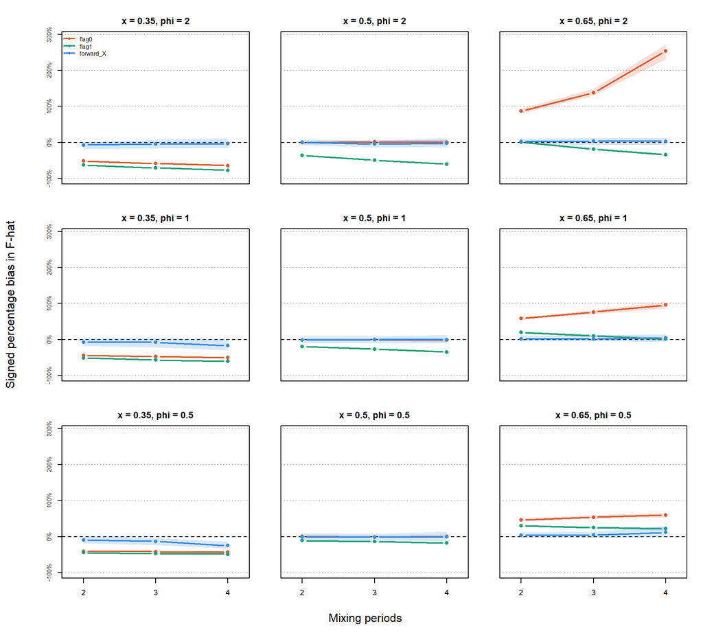

Median signed percentage bias in F across true reporting rate, mixing-period length, and tagged-fish availability. Shaded bands are the central 50% of replicate estimates.

When the true reporting rate is lower than the assumed rate, both flags under-remove tags and underestimate $F$. When the true reporting rate is higher than assumed, `flag0` over-removes and overestimates $F$; `flag1` also moves upward to some extent as the extra true recaptures during mixing leave fewer tags available after the deterministic face-value removal, but remains the lower flag treatment. Performance generally degrades as the mixing period lengthens: errors accumulate over more deterministic mixing periods, and the spread represented by the ribbon tends to widen as well. The two flag settings also do not bound the $F$ estimate: because `flag0` is always the higher flag treatment when the assumed reporting rate is below one, the pair can sit entirely above or below the truth rather than enclosing it.

## Estimated reporting rates and the mis-scaled terms

This check activates the term-content effect of What the likelihood terms contain in the same stripped-down operating model. Reporting rate is now estimated with a log-scale tag-seeding prior centred at $X = 0.5$, the flag removals run as before, and the mixing-period likelihood terms are formed exactly as MULTIFAN-CL forms them: predicted reported returns equal the estimated rate times the removal the flag actually made. Each condition is fitted twice on identical data, with the mixing terms included and excluded, so the difference isolates what those terms alone do. Because the outcome depends on how strongly the prior resists the mis-scaled terms, the whole design is run at two prior widths: the weak single-group prior used for `forward_X` above ($\mathrm{sd} = 0.25$ on $\log X$) and a tight one ($\mathrm{sd} = 0.05$) standing in for the stronger reporting-rate information an assessment carries.

Two deterministic checks precede the fits — the mixing-term block of the objective is invariant to the estimated rate under the raised removal, and strictly decreasing toward $X = 1$ under the face-value removal. The render then fails unless, in every condition and at both prior widths, the face-value fits with the terms included return a higher fitted rate and a lower fitted $F$ than the paired fits with them excluded; the raised fits are unchanged by the terms; and the tighter prior reduces the face-value inflation without removing it.

| Prior sd | True X | Removal | Mixing terms | Median fitted X | Median F bias | Converged |
| --- | --- | --- | --- | --- | --- | --- |
| 0.05 | 0.35 | face value (flag 1) | excluded | 0.487 | -49.4% | 100% |
| 0.25 | 0.35 | face value (flag 1) | excluded | 0.332 | -19.3% | 100% |
| 0.05 | 0.35 | face value (flag 1) | included | 0.764 | -69.9% | 100% |
| 0.25 | 0.35 | face value (flag 1) | included | 0.977 | -77.0% | 100% |
| 0.05 | 0.35 | raised (flag 0) | excluded | 0.484 | -41.5% | 100% |
| 0.25 | 0.35 | raised (flag 0) | excluded | 0.370 | -9.7% | 100% |
| 0.05 | 0.35 | raised (flag 0) | included | 0.484 | -41.5% | 100% |
| 0.25 | 0.35 | raised (flag 0) | included | 0.370 | -9.7% | 100% |
| 0.05 | 0.50 | face value (flag 1) | excluded | 0.489 | -17.4% | 100% |
| 0.25 | 0.50 | face value (flag 1) | excluded | 0.434 | -4.6% | 100% |
| 0.05 | 0.50 | face value (flag 1) | included | 0.808 | -55.5% | 100% |
| 0.25 | 0.50 | face value (flag 1) | included | 0.978 | -64.4% | 100% |
| 0.05 | 0.50 | raised (flag 0) | excluded | 0.500 | -1.6% | 100% |
| 0.25 | 0.50 | raised (flag 0) | excluded | 0.499 | -1.0% | 100% |
| 0.05 | 0.50 | raised (flag 0) | included | 0.500 | -1.6% | 100% |
| 0.25 | 0.50 | raised (flag 0) | included | 0.499 | -1.0% | 100% |
| 0.05 | 0.65 | face value (flag 1) | excluded | 0.521 | 14.7% | 100% |
| 0.25 | 0.65 | face value (flag 1) | excluded | 0.568 | 1.6% | 100% |
| 0.05 | 0.65 | face value (flag 1) | included | 0.839 | -37.6% | 100% |
| 0.25 | 0.65 | face value (flag 1) | included | 0.978 | -48.2% | 100% |
| 0.05 | 0.65 | raised (flag 0) | excluded | 0.567 | 26.6% | 100% |
| 0.25 | 0.65 | raised (flag 0) | excluded | 0.639 | 2.5% | 100% |
| 0.05 | 0.65 | raised (flag 0) | included | 0.567 | 26.6% | 100% |
| 0.25 | 0.65 | raised (flag 0) | included | 0.639 | 2.5% | 100% |

Under the raised removal the terms change nothing, at either prior width: fitted rates and $F$ agree whether the terms are included or excluded, which is the cancellation made executable and a control on the face-value result — same code, same data, one flag switch. Under the face-value removal the terms capture the estimate. With the weak prior, at a true rate of 0.5, the median fitted rate moves from 0.43 with the terms excluded to 0.98 with them included, and the median $F$ error from -4.6% to -64.4%; the fitted rate lands at nearly the same value whatever the true rate, which is the signature of an estimate that has stopped responding to the data that identifies it. Tightening the prior fivefold resists but does not remove the pull: the fitted rate then moves from 0.49 to 0.81, and the $F$ error from -17.4% to -55.5%.

The point is not that the reporting rate is inestimable — the excluded columns recover it. The point is that under the face-value setting the mixing terms compete with the seeding prior for control of a parameter that scales every post-mixing prediction, and their preferred value is complete reporting regardless of the data. These magnitudes are properties of the illustrative operating model — one release group, one fishery, Poisson reporting, and fishing mortality informed by tags alone rather than by catch and effort — not of the assessment, where more post-mixing returns and the full set of seeding priors push back harder. What transfers is the structure and the direction. The size of the effect in the assessment is an open, computable question: a `tag_flags(i,2)` comparison of fitted reporting rates against their tag-seeding priors.